# 301.4. Extended Chandra Deep Field South (ECDFS)

For the Rubin Science Platform at data.lsst.cloud.  
Data Release: DP1  
Container Size: large  
LSST Science Pipelines version: r29.2.0  
Last verified to run: 2026-01-30  
Repository: github.com/lsst/tutorial-notebooks

**Learning objective:** To explore the Extended Chandra Deep Field South (ECDFS) target field from commissioning with LSSTComCam, using Data Preview 1 (DP1) data.

**LSST data products:** `deep_coadd`, `CcdVisit`, `Visit`, `Object`

**Packages:** `lsst.rsp`, `lsst.daf.butler`, `lsst.afw.display`

**Credit:** Originally developed by the Rubin Community Science team. Please consider acknowledging them if this notebook is used for the preparation of journal articles, software releases, or other notebooks.

**Get Support:** Everyone is encouraged to ask questions or raise issues in the [Support Category](https://community.lsst.org/c/support) of the Rubin Community Forum. Rubin staff will respond to all questions posted there.

## 1. Introduction

This notebook examines the Data Preview 1 (DP1) data products in the Extended Chandra Deep Field South (ECDFS), including magnitude limits, visit distribution with time, data quality, and the distributions of stars and galaxies in color-magnitude and color-color diagrams.

The [Extended Chandra Deep Field South (ECDFS)](https://en.wikipedia.org/wiki/Chandra_Deep_Field_South) is a popular extragalatic deep field that has attracted a wealth of panchromatic imaging and spectroscopy. The Rubin map of ECDFS is centered at (RA, Dec) = (53.16 -28.10) The region covered spans a diameter of about 1 degree.

**Related tutorials:** The 100-level tutorials demonstrate how to use the butler, the Table Access Protocol (TAP) service, and the Firefly image display. The 200-level tutorials introduce the types of image and catalog data.

### 1.1. Import packages

Import `numpy`, a fundamental package for scientific computing with arrays in Python (numpy.org), and `matplotlib`, a comprehensive library for data visualization ([matplotlib.org](https://matplotlib.org/); [matplotlib gallery](https://matplotlib.org/stable/gallery/index.html)), including custom shapes (`Polygon`) and lines (`mlines`). `itertools` supports efficient iteration and combinatorics.

From the `lsst` package, import modules for accessing the Table Access Protocol (TAP) service, for retrieving datasets from the butler, and for image displaying from the LSST Science Pipelines ([pipelines.lsst.io](https://pipelines.lsst.io/)). Additional modules support spherical geometry (`sphgeom`), 2D geometry (`geom`), and standardized multiband plotting (`lsst.utils.plotting`) for LSST data analysis and visualization.

```python
import numpy as np
import matplotlib.pyplot as plt
import matplotlib.lines as mlines
from matplotlib.patches import Polygon
import itertools

from lsst.rsp import get_tap_service
from lsst.daf.butler import Butler
import lsst.afw.display as afw_display
import lsst.sphgeom as sphgeom
import lsst.geom as geom

from lsst.utils.plotting import (get_multiband_plot_colors,
                                 get_multiband_plot_symbols,
                                 get_multiband_plot_linestyles)
```

### 1.2. Define parameters and functions

Create an instance of the TAP service, and assert that it exists.

```python
service = get_tap_service("tap")
assert service is not None
```

Create an instance of the butler, and assert that it exists.

```python
butler = Butler('dp1', collections="LSSTComCam/DP1")
assert butler is not None
```

Define the approximate central coordinates of the ECDFS in degrees, and the `region` to use when querying for overlapping images.

```python
target_ra = 53.2
target_dec = -28.1

ra_cen = target_ra
dec_cen = target_dec

radius = 1.0
region = sphgeom.Region.from_ivoa_pos(f"CIRCLE {target_ra} {target_dec} {radius}")
```

Define parameters to use colorblind-friendly colors with `matplotlib`.

```python
plt.style.use('seaborn-v0_8-colorblind')
prop_cycle = plt.rcParams['axes.prop_cycle']
colors = prop_cycle.by_key()['color']
```

Define colors, symbols, and linestyles to represent the six LSST filters, $ugrizy$.

```python
filter_colors = get_multiband_plot_colors()
filter_symbols = get_multiband_plot_symbols()
filter_linestyles = get_multiband_plot_linestyles()
```

Set `afwDisplay` to use Firefly to display images, and open Firefly frame 1.

```python
afw_display.setDefaultBackend('firefly')
display = afw_display.Display(frame=1)
```

## 2. Coadded coverage

The individual LSSTLSSTComCam images have been combined (stacked) into `deep_coadd` images, and sky maps of the accumulated exposure time and image depth have been created.

### 2.1. Display a deep coadd

Query the butler for all $r$-band `deep_coadd` images that overlap the defined `region`.

```python
coadd_datasetrefs = butler.query_datasets("deep_coadd",
                                          where="patch.region OVERLAPS region AND band='r'",
                                          bind={"region": region},
                                          with_dimension_records=True,
                                          order_by=["patch.tract"])
```

```python
print('There are %s r-band deep_coadd images.' % len(coadd_datasetrefs))
```

```
There are 82 r-band deep_coadd images.
```

Retrieve the `deep_coadd` image associated with one of the dataset references returned by the butler query.

```python
coadd = butler.get(coadd_datasetrefs[10])
```

Display the image, and set the mask plane to be fully transparent.

```python
display.mtv(coadd)
display.setMaskTransparency(100)
```

### 2.2. Exposure time and depth

Retrieve the entire survey property map of the $r$-band magnitude limit as `hspmap_rmaglim`, and of the $r$-band exposure time as `hspmap_rexptime`.

```python
hspmap_rmaglim = butler.get('deepCoadd_psf_maglim_consolidated_map_weighted_mean',
                            skymap='lsst_cells_v1', band='r')
hspmap_rexptime = butler.get('deepCoadd_exposure_time_consolidated_map_sum',
                             skymap='lsst_cells_v1', band='r')
```

Extract the healsparse map values within the radius of the field center and divide the region into a 250×250 grid. Evaluate each survey property map at these grid points. Replace all negative values (no-data placeholders) with NaN to enable proper map display.

```python
dec_size = radius
ra_size = dec_size / np.cos(np.radians(dec_cen))
ra_min, ra_max = ra_cen - ra_size, ra_cen + ra_size
dec_min, dec_max = dec_cen - dec_size, dec_cen + dec_size

ra = np.linspace(ra_min, ra_max, 250)
dec = np.linspace(dec_min, dec_max, 250)
x, y = np.meshgrid(ra, dec)

values_rmaglim = hspmap_rmaglim.get_values_pos(x, y)
values_rmaglim = np.where(values_rmaglim < 0.0, np.nan, values_rmaglim)

values_rexptime = hspmap_rexptime.get_values_pos(x, y)
values_rexptime = np.where(values_rexptime < 0.0, np.nan, values_rexptime)
```

Clean up.

```python
del ra, dec
```

Print the mean, median, and min/max values for the $r$-band magnitude limit and exposure time. Exposure times are accumulated over multiple visits, not single exposures.

```python
print('r-band magnitude limit mean/median: %5.2f %5.2f' % (np.nanmean(values_rmaglim),
                                                           np.nanmedian(values_rmaglim)))
print('r-band magnitude min/max: %5.2f %5.2f' % (np.nanmin(values_rmaglim),
                                                 np.nanmax(values_rmaglim)))
print('\n')
print('r-band exposure time (s) mean/median: %5.1f %5.1f' % (np.nanmean(values_rexptime),
                                                             np.nanmedian(values_rexptime)))
print('r-band exposure time min/max (s): %5.1f %5.1f' % (np.nanmin(values_rexptime),
                                                         np.nanmax(values_rexptime)))
```

```
r-band magnitude limit mean/median: 26.07 26.34
r-band magnitude min/max: 21.46 27.12


r-band exposure time (s) mean/median: 2433.5 1650.0
r-band exposure time min/max (s):  30.0 6870.0
```

### 2.3. Coverage map

Define unique colors and linestyles for plotting each of the tracts in the dataset.

```python
alltracts = [rec.dataId['tract'] for rec in coadd_datasetrefs]
unique_tracts = np.unique(alltracts)

colors = plt.cm.tab10(np.linspace(0, 1, len(unique_tracts)))
linestyles = ['-', '--', '-.', ':'] * ((len(unique_tracts) // 4) + 1)

style_dict = {
    tract: {'color': colors[i], 'linestyle': linestyles[i]}
    for i, tract in enumerate(unique_tracts)
}
print('unique tracts: ', unique_tracts)
```

```
unique tracts:  [4848 4849 5063 5064]
```

Use TAP to find the vertices of each patch for each of the unique tracts covering the field in the `dp1.coaddPatches` table.

```python
list_unique_tracts = "(" + ", ".join(str(tract) for tract in unique_tracts) + ")"
query = "SELECT lsst_patch, lsst_tract, s_ra, s_dec, s_region " \
        "FROM dp1.CoaddPatches " \
        "WHERE lsst_tract IN {}".format(list_unique_tracts)
job = service.submit_job(query)
job.run()
job.wait(phases=['COMPLETED', 'ERROR'])
print('Job phase is', job.phase)
if job.phase == 'ERROR':
    job.raise_if_error()
```

```
Job phase is COMPLETED
```

Fetch the results as an `astropy` table.

```python
assert job.phase == 'COMPLETED'
coadd_patches = job.fetch_result().to_table()
```

Use `matplotlib.patches.Polygon` along with `ax.add_patch()` to draw each patch outline. Each tract is plotted with a distinct color and linestyle for visual clarity.

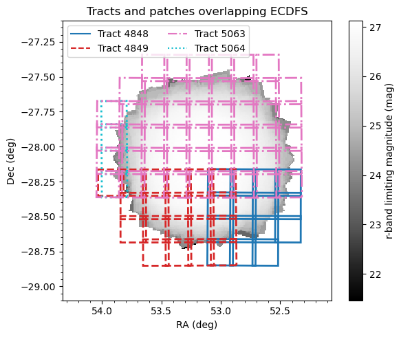

```python
fig, ax = plt.subplots(figsize=(6, 5))

mesh = ax.pcolormesh(x, y, values_rmaglim, cmap='Greys_r', shading='auto')
fig.colorbar(mesh, ax=ax, label="r-band limiting magnitude (mag)")

tracts = set(coadd_patches['lsst_tract'])

for tract in tracts:
    s_regions = coadd_patches[coadd_patches['lsst_tract'] == tract]['s_region']

    for s_region in s_regions:
        coordinates = np.array(s_region.split()[2:], dtype=float)
        ra = coordinates[0::2]
        ra = (ra + 180) % 360 - 180
        dec = coordinates[1::2]
        vertices_deg = np.vstack([ra, dec]).T

        polygon = Polygon(vertices_deg, closed=True, facecolor='None',
                          edgecolor=style_dict[tract]['color'],
                          linestyle=style_dict[tract]['linestyle'],
                          linewidth=2)
        ax.add_patch(polygon)

ax.set_xlim(ra_max, ra_min)
ax.set_ylim(dec_min, dec_max)
ax.set_xlabel('RA (deg)')
ax.set_ylabel('Dec (deg)')

handles = [
    mlines.Line2D([], [], color=style['color'], linestyle=style['linestyle'],
                  label=f"Tract {tract}")
    for tract, style in style_dict.items()
]
ax.legend(handles=handles, loc='upper left', ncol=2)

ax.minorticks_on()
ax.set_title('Tracts and patches overlapping ECDFS')

plt.tight_layout()
plt.show()
```

> **Figure 1:** For the region of the ECDFS, the $r$-band magnitude limit survey property map in greyscale, overplotted with the patch boundaries colored by their tract number (as in the legend).

Clean up.

```python
del coadd_datasetrefs
del hspmap_rmaglim, hspmap_rexptime
del x, y, values_rmaglim, values_rexptime
del style_dict
del tracts, s_regions, coordinates, ra, dec
```

## 3. Visits (observations)

Retrieve all visits (individual observations of the sky) that fall within a circular region centered at (RA, Dec) = (`ra_cen`, `dec_cen`) with a radius of 1 degree. Return the visit ID, band, observation midpoint time in both MJD and calendar date.

```python
query = """
        SELECT visit, band, expMidptMJD, expMidpt
        FROM dp1.Visit
        WHERE CONTAINS(POINT('ICRS', ra, dec),CIRCLE('ICRS', {}, {}, {}))=1
        """.format(ra_cen, dec_cen, radius)
```

```python
job = service.submit_job(query)
job.run()
job.wait(phases=['COMPLETED', 'ERROR'])
print('Job phase is', job.phase)
if job.phase == 'ERROR':
    job.raise_if_error()
```

```
Job phase is COMPLETED
```

```python
assert job.phase == 'COMPLETED'
visits = job.fetch_result().to_table()
print(f"Total number of visits: {len(visits)}")
```

```
Total number of visits: 855
```

Option to display the table of results.

```python
# visits
```

### 3.1. Filter distribution

Count and list the number of visits per filter.

```python
all_bands = np.array([visit['band'] for visit in visits], dtype=str)
unique_bands, counts = np.unique(all_bands, return_counts=True)

for band, count in zip(unique_bands, counts):
    print(band, count)
```

```
g 230
i 162
r 237
u 43
y 30
z 153
```

```python
field_filters = ['u', 'g', 'r', 'i', 'z', 'y']
```

Clean up.

```python
del all_bands, unique_bands, counts
```

### 3.2. Visit dates

Plot two characteristics of the visit dates:

1. Plot the cumulative distribution of visit dates for each of the filters observed for this field.
2. Plot the distribution of the time separation between visits for each band and for all bands combined.

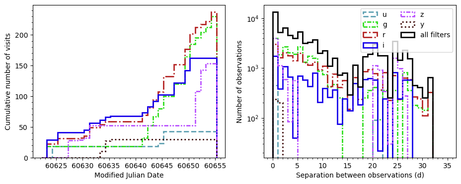

```python
t_start = visits[0]['expMidptMJD'] - 1.0
t_end = visits[-1]['expMidptMJD'] + 1.0
time_bins = np.arange(t_end - t_start, dtype='int') + t_start
diff_bins = np.arange(0, np.max(time_bins) - np.min(time_bins) + 3, 1)
all_time_diffs = []

fig, (ax1, ax2) = plt.subplots(1, 2, figsize=(11, 4))

for band in field_filters:
    mjds = sorted([
        visit['expMidptMJD']
        for visit in visits
        if visit['band'] == band
    ])
    mjds = np.array(mjds, dtype=float)
    label = f"{band} ({len(mjds)})"

    counts, _, patches = ax1.hist(
        mjds, bins=time_bins, cumulative=True, histtype='step',
        linewidth=2, color=filter_colors[band], label=label
    )
    for patch in patches:
        patch.set_linestyle(filter_linestyles[band])

    tdiffs = []
    for comb in itertools.combinations(mjds, 2):
        tdiffs.append(comb[1] - comb[0])
    time_diffs = np.array(tdiffs)
    all_time_diffs.append(time_diffs)

    counts_diff, _, patches_diff = ax2.hist(
        time_diffs, bins=diff_bins, histtype='step', linewidth=2,
        color=filter_colors[band], label=band
    )
    for patch in patches_diff:
        patch.set_linestyle(filter_linestyles[band])

all_time_diffs = np.concatenate(all_time_diffs)
ax2.hist(
    all_time_diffs, bins=diff_bins, histtype='step', linewidth=2,
    color='black', label='all filters'
)

ax1.set_xlabel('Modified Julian Date')
ax1.set_ylabel('Cumulative number of visits')
ax1.minorticks_on()

ax2.set_xlabel('Separation between observations (d)')
ax2.set_ylabel('Number of observations')
ax2.set_yscale('log')
ax2.legend(loc='upper right', ncol=2)
ax2.minorticks_on()

plt.show()
```

> **Figure 2:** The left panel shows the cumulative number of visits per filter as a function of time. The right panel shows histograms of visit-to-visit time separations for each filter individually (colors), and all together (black).

Clean up.

```python
del time_bins, all_time_diffs
```

### 3.3. Visit image quality

Retrieve statistics about the image quality of the individual `visit_images` from the `CcdVisit` table.

```python
query = """
        SELECT visitId, ra, dec, band, magLim, seeing
        FROM dp1.CcdVisit
        WHERE CONTAINS(POINT('ICRS', ra, dec),CIRCLE('ICRS', {}, {}, {}))=1
        """.format(ra_cen, dec_cen, radius)
```

```python
job = service.submit_job(query)
job.run()
job.wait(phases=['COMPLETED', 'ERROR'])
print('Job phase is', job.phase)
if job.phase == 'ERROR':
    job.raise_if_error()
```

```
Job phase is COMPLETED
```

```python
assert job.phase == 'COMPLETED'
ccd_visits = job.fetch_result().to_table()
```

Plot the distribution of `seeing`, which is the mean full width at half maximum of the PSF, for all visits and detector combinations.

```
Median in u-band:              1.40
Median in g-band:              1.14
Median in r-band:              1.08
Median in i-band:              1.00
Median in z-band:              1.00
Median in y-band:              1.07
```

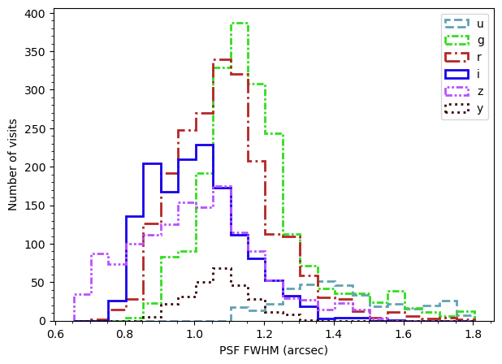

```python
min_seeing = np.min(ccd_visits['seeing'])
max_seeing = np.max(ccd_visits['seeing'])
seeing_bins = np.arange(min_seeing, max_seeing, 0.05)

fig = plt.figure(figsize=(7, 5))
for band in field_filters:
    print(f"Median in {band}-band: \
            {np.ma.median(ccd_visits[ccd_visits['band'] == band]['seeing']): .2f}")
    n, bins, patches = plt.hist(ccd_visits[ccd_visits['band'] == band]['seeing'],
                                seeing_bins, histtype='step',
                                linewidth=2,
                                color=filter_colors[band],
                                label=band)
    for patch in patches:
        patch.set_linestyle(filter_linestyles[band])

plt.legend(loc='upper right')
plt.xlabel('PSF FWHM (arcsec)')
plt.ylabel('Number of visits')
plt.minorticks_on()
plt.show()
```

> **Figure 3:** Histogram of delivered image quality of detector images, per filter.

Clean up.

```python
del seeing_bins
```

Plot the distribution of the magnitude limit, `magLim`.

```
Median in u-band:              23.48
Median in g-band:              24.68
Median in r-band:              24.38
Median in i-band:              23.97
Median in z-band:              23.15
Median in y-band:              21.93
```

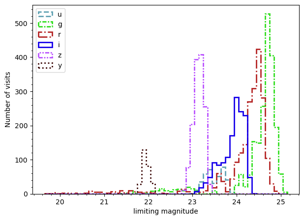

```python
min_mag = np.min(ccd_visits['magLim'])
max_mag = np.max(ccd_visits['magLim'])
maglim_bins = np.arange(min_mag, max_mag, 0.1)

fig = plt.figure(figsize=(7, 5))

for band in field_filters:
    print(f"Median in {band}-band: \
            {np.ma.median(ccd_visits[ccd_visits['band'] == band]['magLim']): .2f}")
    n, bins, patches = plt.hist(ccd_visits[ccd_visits['band'] == band]['magLim'],
                                maglim_bins, histtype='step',
                                linewidth=2,
                                color=filter_colors[band],
                                label=band)
    for patch in patches:
        patch.set_linestyle(filter_linestyles[band])

plt.legend(loc='upper left')
plt.xlabel('limiting magnitude')
plt.ylabel('Number of visits')
plt.minorticks_on()
plt.show()
```

> **Figure 4:** Histogram of limiting magnitude at signal-to-noise=5 on detector images, per filter.

Clean up.

```python
del maglim_bins
```

## 4. Object (detections)

The `Object` table contains forced measurements on the deep coadded images at the locations of all objects detected with signal-to-noise ratio > 5 in a `deep_coadd` of any filter.

Query the `Object` table for objects in the field, and return their `PSF` and `cModel` AB magnitudes.

```python
query = """SELECT objectId, coord_ra, coord_dec, ebv,
        {}_psfMag, {}_cModelMag, {}_psfMag, {}_cModelMag,
        {}_psfMag, {}_cModelMag, {}_psfMag, {}_cModelMag,
        {}_psfMag, {}_cModelMag, {}_psfMag, {}_cModelMag,
        refExtendedness
        FROM dp1.Object
        WHERE CONTAINS(POINT('ICRS', coord_ra, coord_dec),
              CIRCLE('ICRS', {}, {}, {})) = 1
        """.format(field_filters[0], field_filters[0], field_filters[1], field_filters[1],
                   field_filters[2], field_filters[2], field_filters[3], field_filters[3],
                   field_filters[4], field_filters[4], field_filters[5], field_filters[5],
                   ra_cen, dec_cen, radius)
print(query)
```

```
SELECT objectId, coord_ra, coord_dec, ebv,
        u_psfMag, u_cModelMag, g_psfMag, g_cModelMag,
        r_psfMag, r_cModelMag, i_psfMag, i_cModelMag,
        z_psfMag, z_cModelMag, y_psfMag, y_cModelMag,
        refExtendedness
        FROM dp1.Object
        WHERE CONTAINS(POINT('ICRS', coord_ra, coord_dec),
              CIRCLE('ICRS', 53.2, -28.1, 1.0)) = 1
```

```python
job = service.submit_job(query)
job.run()
job.wait(phases=['COMPLETED', 'ERROR'])
print('Job phase is', job.phase)
if job.phase == 'ERROR':
    job.raise_if_error()
```

```
Job phase is COMPLETED
```

```python
assert job.phase == 'COMPLETED'
objtab = job.fetch_result().to_table()
```

### 4.1. Magnitude distributions

Plot histograms of object magnitudes, separating the samples into stars and galaxies.

Use the `refExtendedness` flag to distinguish them: treat objects with `refExtendedness == 1` as likely galaxies (extended) and those with `refExtendedness == 0` as likely stars (point sources).

Use `cModelMag` mags for galaxies and `psfMag` for stars.

```python
ptsource = (objtab['refExtendedness'] == 0)
```

```
Number of objects in u-band: 368728
Number of objects in g-band: 442595
Number of objects in r-band: 437816
Number of objects in i-band: 440706
Number of objects in z-band: 424969
Number of objects in y-band: 341877
```

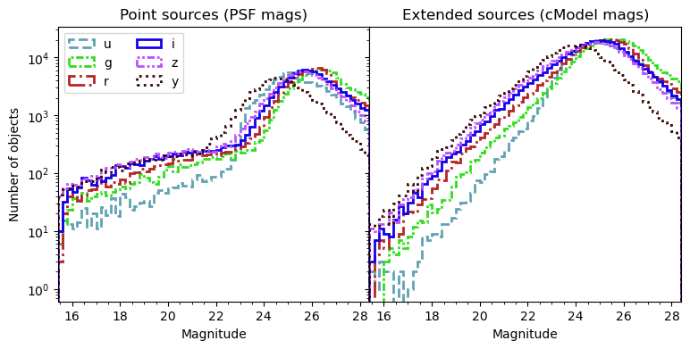

```python
mag_bins = np.arange(15.4, 28.6, 0.2)

fig, (ax1, ax2) = plt.subplots(1, 2, figsize=(9, 4), sharey=True)
plt.subplots_adjust(hspace=0, wspace=0)

for band in field_filters:
    mag_psf = objtab[f"{band}_psfMag"]
    mag_cmodel = objtab[f"{band}_cModelMag"]

    valid_mags = (15 < mag_psf) & (mag_psf < 30) & (15 < mag_cmodel) & (mag_cmodel < 30)

    print(f"Number of objects in {band}-band: {np.sum(valid_mags)}")

    n_psf, bins_psf, patches_psf = ax1.hist(mag_psf[valid_mags & ptsource], bins=mag_bins,
                                            histtype='step', linewidth=2,
                                            color=filter_colors[band], label=band,)
    for patch in patches_psf:
        patch.set_linestyle(filter_linestyles[band])

    n_cmodel, bins_cmodel, patches_cmodel = ax2.hist(
        mag_cmodel[valid_mags & ~ptsource],
        bins=mag_bins,
        histtype='step',
        linewidth=2,
        color=filter_colors[band],
        label=band,
    )
    for patch in patches_cmodel:
        patch.set_linestyle(filter_linestyles[band])

ax1.set_xlim(mag_bins.min(), mag_bins.max())
ax1.set_yscale('log')
ax1.set_xlabel('Magnitude')
ax1.set_ylabel('Number of objects')
ax1.set_title('Point sources (PSF mags)')
ax1.legend(loc='upper left', ncols=2)
ax1.minorticks_on()

ax2.set_xlim(mag_bins.min(), mag_bins.max())
ax2.set_xlabel('Magnitude')
ax2.set_title('Extended sources (cModel mags)')
ax2.minorticks_on()

plt.show()
```

Clean up.

```python
del mag_bins, mag_psf, mag_cmodel, valid_mags, n_psf, bins_psf, patches_psf
del n_cmodel, bins_cmodel, patches_cmodel
```

## 5. Analysis

A short demonstration of some standard scientific analyses.

### 5.1. Color magnitude diagram

Plot $r$ vs. $(g - r)$ CMDs and $(r - i)$ vs. $(g - r)$ CCDs. Create separate plots for stars and galaxies using `PSF` magnitudes for stars and `cModel` magnitudes for galaxies.

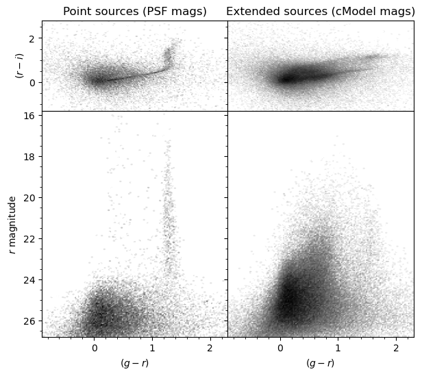

```python
fig, ((ax1, ax2), (ax3, ax4)) = plt.subplots(2, 2, figsize=(7, 6),
                                             height_ratios=[1, 2.5])
plt.subplots_adjust(hspace=0, wspace=0)

grmin, grmax = -0.9, 2.3
rimin, rimax = -1.3, 2.8
magmin, magmax = 15.8, 26.8

ax1.hexbin(objtab[ptsource]['g_psfMag']-objtab[ptsource]['r_psfMag'],
           objtab[ptsource]['r_psfMag']-objtab[ptsource]['i_psfMag'],
           gridsize=(150, 150),
           extent=(grmin, grmax, rimin, rimax), bins='log', cmap='Grays')
ax1.set_title('Point sources (PSF mags)')
ax1.set_xlim(grmin, grmax)
ax1.set_ylim(rimin, rimax)
ax1.set_ylabel(r'$(r-i)$')
ax1.set_xticklabels([])
ax1.minorticks_on()

ax2.hexbin(objtab[~ptsource]['g_cModelMag']-objtab[~ptsource]['r_cModelMag'],
           objtab[~ptsource]['r_cModelMag']-objtab[~ptsource]['i_cModelMag'],
           gridsize=(150, 150),
           extent=(grmin, grmax, rimin, rimax), bins='log', cmap='Grays')
ax2.set_title('Extended sources (cModel mags)')
ax2.set_xlim(grmin, grmax)
ax2.set_ylim(rimin, rimax)
ax2.set_xticklabels([])
ax2.set_yticklabels([])
ax2.minorticks_on()

ax3.hexbin(objtab[ptsource]['g_psfMag']-objtab[ptsource]['r_psfMag'],
           objtab[ptsource]['r_psfMag'], gridsize=(150, 200),
           extent=(grmin, grmax, magmin, magmax), bins='log', cmap='Grays')

ax3.set_xlim(grmin, grmax)
ax3.set_ylim(magmax, magmin)
ax3.set_xlabel(r'$(g-r)$')
ax3.set_ylabel(r'$r$ magnitude')
ax3.minorticks_on()

ax4.hexbin(objtab[~ptsource]['g_cModelMag']-objtab[~ptsource]['r_cModelMag'],
           objtab[~ptsource]['r_cModelMag'], gridsize=(150, 200),
           extent=(grmin, grmax, magmin, magmax), bins='log', cmap='Grays')
ax4.set_xlim(grmin, grmax)
ax4.set_ylim(magmax, magmin)
ax4.set_xlabel(r'$(g-r)$')
ax4.set_yticklabels([])
ax4.minorticks_on()

plt.show()
```

> **Figure 6:** CMDs and CCDs for objects classified by morphology. The left column shows likely stars (`refExtendedness` = 0) using `PSF` magnitudes, and the right column shows likely galaxies using `cModel` magnitudes. Top panels display $(r - i)$ vs. $(g - r)$ CCDs; bottom panels show $r$ vs. $(g - r)$ CMDs.

### 5.2. Galaxy evolution analyses

This section demonstrates a few tasks more specific to galaxy evolution analyses since the ECDFS is a popular well-studied extragalactic field. Two aspects are performed below:

1. First zoom in on the hubble ultra-deep field as a visual comparison to complementary datasets.
2. Color selection of high-redshift galaxies at redshift z~4, using a standard Lyman-break selection technique (optionally compare to some literature coordinates?)

First, to enable easier comparison to other data set the afw backend to matplotlib.

```python
afw_display.setDefaultBackend('matplotlib')
```

Below, define the central coordinates of the Hubble Ultra Deep Field South (e.g. Beckwith et al. 2006; Ellis et al. 2013; Koekemoer et al. 2013). Then, identify the data ID of ECDFS `deep_coadd` r-band image that contains this region of the sky.

```python
hudf_ra = 53.159
hudf_dec = -27.7815854
center_coadd_datasetrefs = butler.query_datasets("deep_coadd",
                                                 where="band.name='r' AND\
                                                        patch.region OVERLAPS POINT(ra, dec)",
                                                 bind={"ra": hudf_ra, "dec": hudf_dec},
                                                 with_dimension_records=True,
                                                 order_by=["patch.tract"])
coadd = butler.get(center_coadd_datasetrefs[0])
dataId = center_coadd_datasetrefs[0].dataId
```

The cell below will ask the Butler to generate a cutout that is 2500 LSST pixels on a side (8.3 x 8.3 arcmin) centered on the HUDF. Compare to a cutout of the same part of the sky from Hubble Space Telescope F606W imaging (similar effective wavelength to LSST r-band).

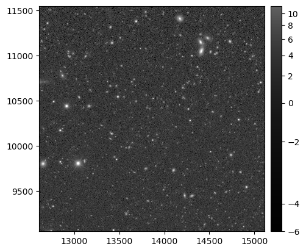

```python
wcs = butler.get("deep_coadd.wcs", dataId=dataId)
radec_hudf = geom.SpherePoint(hudf_ra, hudf_dec, geom.degrees)
xy_hudf = geom.PointI(wcs.skyToPixel(radec_hudf))

cutoutSize = geom.ExtentI(2500, 2500)
bbox = geom.BoxI(xy_hudf - cutoutSize // 2, cutoutSize)
parameters = {'bbox': bbox}
cutout_image = butler.get('deep_coadd', parameters=parameters, dataId=dataId)

fig, ax = plt.subplots()
display = afw_display.Display(frame=fig)
display.scale('asinh', 'zscale')
display.mtv(cutout_image.image)
plt.show()
```

> Figure 6: Cutout of the region of ECDFS containing the Hubble Ultra Deep Field.

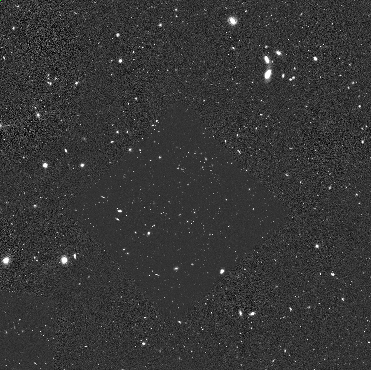

> Figure 7: a screenshot of a Hubble Space Telescope V-band (F606W; 0.6 micron wavelength) image of the same region.

### 5.3. Select candidate high-redshift galaxies

The cell below demonstrates the color selection of high-redshift galaxies in the LSST ECFDS `deep_coadd` images by identifying galaxies with a strong Lyman-break at redshift $\sim4$ (i.e., $g$-band dropouts). The colors defined below reference the selection defined in [Overzier et al. 2006](https://ui.adsabs.harvard.edu/abs/2006ApJ...648L...5O/abstract) which uses similar filtersets to the LSST filters.

First, query the `Object` table to return `cModelFlux` values $ugriz$ filters for galaxies (`r_extendedness`=1) that are well-detected (with signal to noise ratio greater than 20 in the $r$ and $i$ bands).

```python
query_lines = [
    "SELECT objectId, coord_ra, coord_dec, i_extendedness, "
]

for filt in field_filters:
    query_lines.append(f"       {filt}_cModelFlux, {filt}_cModelFluxErr, ")
    query_lines.append(f"       {filt}_cModelMag AS {filt}mag, "
                       f"{filt}_cModelMagErr AS {filt}magErr, ")

query_lines.append("       refExtendedness")
query_lines.append("FROM dp1.Object")
query_lines.append(
    f"WHERE CONTAINS(POINT('ICRS', coord_ra, coord_dec), "
    f"CIRCLE('ICRS', {ra_cen}, {dec_cen}, {radius})) = 1 "
    f"AND r_cModelFlux/r_cModelFluxErr > 20 "
    f"AND i_cModelFlux/i_cModelFluxErr > 20"
    f"AND r_extendedness = 1"
)

query = "\n".join(query_lines)
print(query)
```

```
SELECT objectId, coord_ra, coord_dec, i_extendedness,
       u_cModelFlux, u_cModelFluxErr,
       u_cModelMag AS umag, u_cModelMagErr AS umagErr,
       g_cModelFlux, g_cModelFluxErr,
       g_cModelMag AS gmag, g_cModelMagErr AS gmagErr,
       r_cModelFlux, r_cModelFluxErr,
       r_cModelMag AS rmag, r_cModelMagErr AS rmagErr,
       i_cModelFlux, i_cModelFluxErr,
       i_cModelMag AS imag, i_cModelMagErr AS imagErr,
       z_cModelFlux, z_cModelFluxErr,
       z_cModelMag AS zmag, z_cModelMagErr AS zmagErr,
       y_cModelFlux, y_cModelFluxErr,
       y_cModelMag AS ymag, y_cModelMagErr AS ymagErr,
       refExtendedness
FROM dp1.Object
WHERE CONTAINS(POINT('ICRS', coord_ra, coord_dec), CIRCLE('ICRS', 53.2, -28.1, 1.0)) = 1 AND r_cModelFlux/r_cModelFluxErr > 20 AND i_cModelFlux/i_cModelFluxErr > 20AND r_extendedness = 1
```

```python
job = service.submit_job(query)
job.run()
job.wait(phases=['COMPLETED', 'ERROR'])
print('Job phase is', job.phase)
if job.phase == 'ERROR':
    job.raise_if_error()
```

```
Job phase is COMPLETED
```

```python
assert job.phase == 'COMPLETED'
results = job.fetch_result().to_table()
```

The color selection requires a robust measurement of the g-r color, but g-band dropouts are not detected, so color cannot be robustly recovered from the flux measurement. Instead, get a lower limit on how red it is using the g-band flux error (i.e. use the upper limit to the g-band flux to measure the g-r color). To do this, define a new parameter called `gmag` to store the g-band magnitude error, for use in measuring colors. In this case, if sources have signal to noise less than 1 in g_band, gmag will instead hold the `gmagErr` from the object table.

> **Warning:** the following cell produces a pink UserWarning that masked elements from the `results` array are converted to `nan` (not a number) in the `gmag` array; this is correct behavior, and can be ignored.

```python
gmag = np.zeros(len(results['gmag']), dtype='float')
S2N = np.asarray(results['g_cModelFlux']/results['g_cModelFluxErr'], dtype='float')

for i in range(len(gmag)):
    if S2N[i] < 1:
        gmag[i] = results['gmagErr'][i]
    else:
        gmag[i] = results['gmag'][i]
```

```
/tmp/ipykernel_12234/914783169.py:8: UserWarning: Warning: converting a masked element to nan.
  gmag[i] = results['gmag'][i]
/tmp/ipykernel_12234/914783169.py:6: UserWarning: Warning: converting a masked element to nan.
  gmag[i] = results['gmagErr'][i]
```

The cell below will identify Lyman-break galaxies (LBG) using the colors defined by Overzier et al. 2006.

```python
GRlim = 1.5

whlbg = np.where(((gmag-results['rmag']) > 1.5)
                 & ((results['gmag'] - results['rmag'])
                    > (results['rmag'] - results['zmag'] + 1.1))
                 & ((results['rmag'] - results['zmag']) < 1.0))[0]
```

Plot the g-r vs r-z color color diagram. The plot shows the colors of the galaxies in the object table (blue) and those with colors consistent with z~4 galaxies (green).

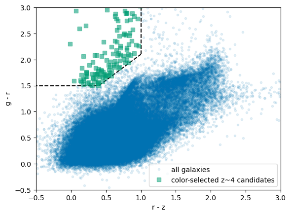

```python
RmZ = np.arange(0.4, 1.1, 0.1)

plt.plot(RmZ, RmZ + 1.1, '--', color='k')
plt.plot([1., 1.], [2.1, 3], '--', color='k')
plt.plot([-1, 0.4], [1.5, 1.5], '--', color='k')

RminusZ = results['rmag'] - results['zmag']
GminusR = gmag - results['rmag']

plt.plot(RminusZ, GminusR, '.', label='all galaxies', alpha=.1)
plt.plot(RminusZ[whlbg], GminusR[whlbg], 's', alpha=.5,
         label='color-selected z~4 candidates')

plt.xlabel('r - z')
plt.ylabel('g - r')
plt.xlim([-0.5, 3])
plt.ylim([-0.5, 3])
plt.legend()
plt.show()
```

> Figure 9: g - r vs r - z color color diagram for galaxies with S/N > 20 in the ECDFS field (blue). Galaxies with blue r-z colors and red g-r colors consistent with with a lyman-break at redshift z=4 are in green.